# Input-Output Model for Kenya’s Sectoral Analysis

Based on the Kenya Economic Survey 2025 (KNBS)

Noah W. Wasike — Econometrician

2026-04-18

# 1 Executive Summary

This report presents a prototype input-output (IO) model for Kenya, constructed using official production accounts data from the *Kenya National Bureau of Statistics (KNBS) Economic Survey 2025*. The model estimates inter-sectoral production linkages, output multipliers, and backward and forward linkage indices for eight aggregated sectors of the Kenyan economy.

The results support the case for targeted industrial policy and provide a quantitative basis for assessing sectoral spillovers from fiscal stimulus and structural transformation strategies.

# 2 Introduction

An input-output framework provides a structured approach to analysing interdependencies across sectors in an economy. Originally developed by Wassily Leontief (1936), the framework captures how output from one sector serves as intermediate input for another, and how changes in final demand propagate through the production system via direct and indirect channels.

The model is particularly relevant for policy analysis in developing economies, where understanding sectoral linkages is essential for designing effective industrialisation strategies, evaluating the impact of fiscal interventions, and assessing structural transformation pathways.

This report constructs a prototype IO model using **real data** from the [Kenya National Bureau of Statistics (KNBS) Economic Survey 2025](https://www.knbs.or.ke), drawing on **Table 2.1** (GDP by Activity), **Table 2.4** (Growth Rates), and **Table 2.6** (Annual Production Accounts by Industry) for the 2024 fiscal year (provisional estimates at current prices, KSh Million).

The model demonstrates:

- Estimation of inter-sectoral production linkages
- Computation of output multipliers
- Backward and forward linkage analysis
- Demand shock simulation and spillover assessment

# 3 Analytical Framework

## 3.1 Theoretical Foundation

The model follows a **demand-driven input-output framework**, where total output is determined as a function of inter-industry relationships and final demand. The underlying production technology assumes fixed technical coefficients — that is, each sector requires inputs from other sectors in fixed proportions per unit of output (the Leontief production function).

The fundamental accounting identity for sector $i$ is:

$$X_i = \sum_{j=1}^{n} z_{ij} + F_i$$

where $X_i$ is total output, $z_{ij}$ is the intermediate delivery from sector $i$ to sector $j$, and $F_i$ is final demand for sector $i$’s output (consumption, investment, government spending, and net exports).

## 3.2 Model Specification

Defining the **technical coefficients matrix** $\mathbf{A}$ with elements $a_{ij} = z_{ij} / X_j$, the system can be expressed in matrix form as:

$$\mathbf{X} = \mathbf{A}\mathbf{X} + \mathbf{F}$$

Solving for total output yields the **Leontief demand model**:

$$\mathbf{X} = (\mathbf{I} - \mathbf{A})^{-1} \mathbf{F}$$

The matrix $\mathbf{L} = (\mathbf{I} - \mathbf{A})^{-1}$ is the **Leontief inverse**, whose elements $l_{ij}$ capture the total (direct + indirect) output required from sector $i$ per unit of final demand for sector $j$.

## 3.3 Key Analytical Concepts

| Concept | Formula | Interpretation |
| --- | --- | --- |
| Technical coefficient | $a_{ij} = z_{ij} / X_j$ | Input from sector *i* per unit of output in sector *j* |
| Output multiplier | $m_j = \sum_i l_{ij}$ | Total output generated economy-wide per unit increase in final demand of sector *j* |
| Backward linkage (BL) | Normalised column sum of $\mathbf{L}$ | Extent to which a sector draws inputs from the rest of the economy |
| Forward linkage (FL) | Normalised row sum of $\mathbf{L}$ | Extent to which a sector supplies inputs to other sectors |

Sectors with both BL > 1 and FL > 1 are classified as **key sectors** — they are strongly integrated into the production system both as purchasers and suppliers of intermediate goods (Rasmussen, 1956; Hirschman, 1958).

# 4 Data

## 4.1 Source and Scope

The model draws on 2024 provisional data from **Table 2.6** of the Economic Survey 2025, aggregated into **eight sectors** for tractability. All values are in **KSh Million at current prices**.

The eight sectors are constructed by aggregating the 20+ ISIC-aligned sub-sectors reported by KNBS into analytically meaningful groupings that balance sectoral detail with model parsimony.

```r
# ── Sector labels ──
sectors <- c(
  "Agriculture",
  "Manufacturing",
  "Construction",
  "Trade",
  "Transport",
  "Financial",
  "ICT",
  "Public Services"
)

n <- length(sectors)

# ── Total output at basic prices (KSh Million, 2024*) ──
# Source: Table 2.6, Economic Survey 2025 (KNBS)
#
# Sector aggregation:
#   Agriculture     = Agriculture, forestry & fishing
#   Manufacturing   = Manufacturing + Mining & quarrying + Electricity supply
#                     + Water supply, sewerage & waste management
#   Construction    = Construction
#   Trade           = Wholesale & retail trade; repairs
#   Transport       = Transportation & storage
#   Financial       = Financial & insurance activities
#   ICT             = Information & communication
#   Public Services = Public administration & defence + Education
#                     + Health & social work + Real estate
#                     + Professional, scientific & technical activities
#                     + Administrative & support service activities
#                     + Accommodation & food services + Other services
#                     + Activities of households as employers

total_output <- c(
  4476418,     # Agriculture
  4435186,     # Manufacturing (3,691,742 + 218,471 + 455,966 + 69,007)
  2171266,     # Construction
  2412339,     # Trade
  3484863,     # Transport & storage
  1614214,     # Financial & insurance
  701267,      # ICT
  5758435      # Public services (aggregated)
)

# ── Total intermediate consumption (KSh Million, 2024*) ──
intermediate_consumption <- c(
  830316,      # Agriculture
  2831010,     # Manufacturing (2,515,349 + 109,501 + 96,659 + 109,501)
  1144143,     # Construction
  1192628,     # Trade
  1423903,     # Transport & storage
  329373,      # Financial & insurance
  336724,      # ICT
  1784770      # Public services (aggregated)
)

# ── Value added = Output - Intermediate consumption ──
value_added <- total_output - intermediate_consumption

# ── Final demand (approximated from GDP contribution, Table 2.1, 2024*) ──
final_demand <- c(
  3646102,     # Agriculture
  1285363,     # Manufacturing
  1027123,     # Construction
  1219711,     # Trade
  2060960,     # Transport & storage
  1284840,     # Financial & insurance
  364542,      # ICT
  3973894      # Public services
)

names(total_output) <- sectors
names(intermediate_consumption) <- sectors
names(value_added) <- sectors
names(final_demand) <- sectors
```

## 4.2 Overview of Sectoral Accounts

```r
accounts_df <- data.frame(
  Sector = sectors,
  `Output (KSh M)` = format(total_output, big.mark = ","),
  `Intermediate Consumption (KSh M)` = format(intermediate_consumption, big.mark = ","),
  `Value Added (KSh M)` = format(value_added, big.mark = ","),
  `IC/Output Ratio` = round(intermediate_consumption / total_output, 3),
  check.names = FALSE
)

knitr::kable(accounts_df,
             caption = "Table 1: Sectoral Production Accounts, Kenya 2024 (KSh Million)",
             align = c("l", rep("r", 4)))
```

Table 1: Sectoral Production Accounts, Kenya 2024 (KSh Million)

|  | Sector | Output (KSh M) | Intermediate Consumption (KSh M) | Value Added (KSh M) | IC/Output Ratio |
| --- | --- | --- | --- | --- | --- |
| Agriculture | Agriculture | 4,476,418 | 830,316 | 3,646,102 | 0.185 |
| Manufacturing | Manufacturing | 4,435,186 | 2,831,010 | 1,604,176 | 0.638 |
| Construction | Construction | 2,171,266 | 1,144,143 | 1,027,123 | 0.527 |
| Trade | Trade | 2,412,339 | 1,192,628 | 1,219,711 | 0.494 |
| Transport | Transport | 3,484,863 | 1,423,903 | 2,060,960 | 0.409 |
| Financial | Financial | 1,614,214 | 329,373 | 1,284,841 | 0.204 |
| ICT | ICT | 701,267 | 336,724 | 364,543 | 0.480 |
| Public Services | Public Services | 5,758,435 | 1,784,770 | 3,973,665 | 0.310 |

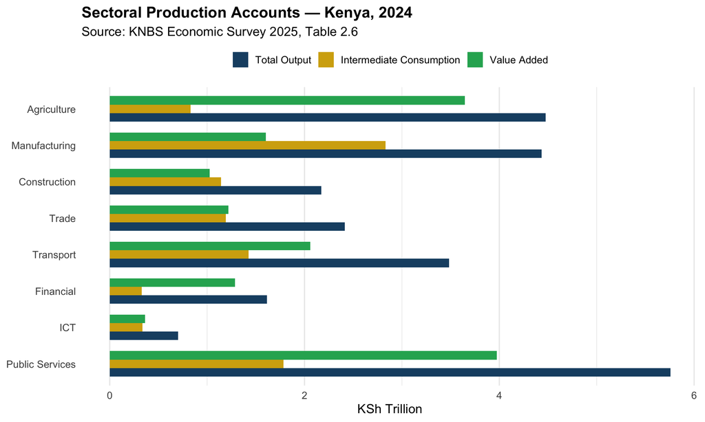

Figure 1: Sectoral Output, Intermediate Consumption and Value Added (2024)

```r
library(ggplot2)

plot_df <- data.frame(
  Sector = rep(sectors, 3),
  Component = rep(c("Total Output", "Intermediate Consumption", "Value Added"), each = n),
  Value = c(total_output, intermediate_consumption, value_added) / 1e6
)
plot_df$Sector <- factor(plot_df$Sector, levels = rev(sectors))
plot_df$Component <- factor(plot_df$Component,
                            levels = c("Total Output", "Intermediate Consumption", "Value Added"))

ggplot(plot_df, aes(x = Sector, y = Value, fill = Component)) +
  geom_bar(stat = "identity", position = "dodge", width = 0.7) +
  coord_flip() +
  scale_fill_manual(values = c("#1B4F72", "#D4AC0D", "#27AE60")) +
  labs(
    title = "Sectoral Production Accounts — Kenya, 2024",
    subtitle = "Source: KNBS Economic Survey 2025, Table 2.6",
    y = "KSh Trillion",
    x = NULL,
    fill = NULL
  ) +
  theme_minimal(base_size = 13) +
  theme(
    legend.position = "top",
    plot.title = element_text(face = "bold"),
    panel.grid.major.y = element_blank()
  )
```

# 5 Model Construction

## 5.1 Estimating the Transaction Matrix

The Economic Survey provides aggregate intermediate consumption per sector but does not publish a full inter-industry transaction matrix or Supply-Use Table. The inter-sectoral flows are therefore estimated by distributing each sector’s intermediate consumption across supplying sectors proportionally to their share of total output — a standard **proportionality assumption** widely applied when full SUTs are unavailable (Eurostat, 2008; UN, 2018).

$$z_{ij} = IC_j \times \frac{X_i}{\sum_k X_k}$$

This assumption implies that each purchasing sector sources its intermediate inputs in the same proportion as the economy-wide output structure. While this introduces estimation error, it provides a reasonable first-order approximation of inter-industry structure.

```r
# ── Estimate inter-industry transaction matrix (Z) ──
output_shares <- total_output / sum(total_output)

Z <- matrix(0, nrow = n, ncol = n)
for (j in 1:n) {
  Z[, j] <- intermediate_consumption[j] * output_shares
}

colnames(Z) <- sectors
rownames(Z) <- sectors

cat("Estimated Transaction Matrix Z (KSh Million, 2024):\n")
```

```
## Estimated Transaction Matrix Z (KSh Million, 2024):
```

```r
print(round(Z, 0))
```

```
##                 Agriculture Manufacturing Construction  Trade Transport
## Agriculture          148353        505819       204425 213088    254410
## Manufacturing        146987        501160       202542 211125    252067
## Construction          71958        245345        99155 103357    123400
## Trade                 79947        272586       110165 114833    137101
## Transport            115492        393777       159144 165888    198057
## Financial             53497        182400        73716  76840     91741
## ICT                   23241         79241        32025  33382     39855
## Public Services      190841        650682       262971 274115    327271
##                 Financial   ICT Public Services
## Agriculture         58849 60163          318886
## Manufacturing       58307 59609          315949
## Construction        28545 29182          154674
## Trade               31714 32422          171848
## Transport           45814 46836          248251
## Financial           21221 21695          114992
## ICT                  9219  9425           49956
## Public Services     75703 77393          410213
```

## 5.2 Technical Coefficients Matrix

The technical coefficients matrix $\mathbf{A}$ describes the production technology of the economy. Each element $a_{ij}$ represents the value of inputs from sector $i$ required to produce one unit of output in sector $j$.

```r
# ── Technical coefficients matrix ──
A <- Z / matrix(total_output, nrow = n, ncol = n, byrow = TRUE)

cat("Technical Coefficients Matrix A:\n")
```

```
## Technical Coefficients Matrix A:
```

```r
print(round(A, 4))
```

```
##                 Agriculture Manufacturing Construction  Trade Transport
## Agriculture          0.0331        0.1140       0.0942 0.0883    0.0730
## Manufacturing        0.0328        0.1130       0.0933 0.0875    0.0723
## Construction         0.0161        0.0553       0.0457 0.0428    0.0354
## Trade                0.0179        0.0615       0.0507 0.0476    0.0393
## Transport            0.0258        0.0888       0.0733 0.0688    0.0568
## Financial            0.0120        0.0411       0.0340 0.0319    0.0263
## ICT                  0.0052        0.0179       0.0147 0.0138    0.0114
## Public Services      0.0426        0.1467       0.1211 0.1136    0.0939
##                 Financial    ICT Public Services
## Agriculture        0.0365 0.0858          0.0554
## Manufacturing      0.0361 0.0850          0.0549
## Construction       0.0177 0.0416          0.0269
## Trade              0.0196 0.0462          0.0298
## Transport          0.0284 0.0668          0.0431
## Financial          0.0131 0.0309          0.0200
## ICT                0.0057 0.0134          0.0087
## Public Services    0.0469 0.1104          0.0712
```

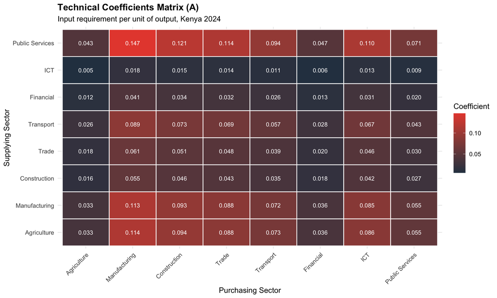

Figure 2: Heatmap of Technical Coefficients Matrix

```r
library(reshape2)

A_melt <- melt(A)
colnames(A_melt) <- c("Supplying_Sector", "Purchasing_Sector", "Coefficient")

ggplot(A_melt, aes(x = Purchasing_Sector, y = Supplying_Sector, fill = Coefficient)) +
  geom_tile(color = "white", linewidth = 0.5) +
  geom_text(aes(label = sprintf("%.3f", Coefficient)), size = 3, color = "white") +
  scale_fill_gradient(low = "#2C3E50", high = "#E74C3C") +
  labs(
    title = "Technical Coefficients Matrix (A)",
    subtitle = "Input requirement per unit of output, Kenya 2024",
    x = "Purchasing Sector",
    y = "Supplying Sector"
  ) +
  theme_minimal(base_size = 11) +
  theme(
    axis.text.x = element_text(angle = 45, hjust = 1),
    plot.title = element_text(face = "bold"),
    legend.position = "right"
  )
```

## 5.3 Leontief Inverse

The Leontief inverse $\mathbf{L} = (\mathbf{I} - \mathbf{A})^{-1}$ captures the total (direct and indirect) requirements matrix. Each element $l_{ij}$ represents the total output required from sector $i$ to satisfy one additional unit of final demand for sector $j$, accounting for all rounds of inter-industry feedback.

```r
# ── Leontief inverse ──
I_mat <- diag(n)
L <- solve(I_mat - A)

colnames(L) <- sectors
rownames(L) <- sectors

cat("Leontief Inverse Matrix L = (I - A)^{-1}:\n")
```

```
## Leontief Inverse Matrix L = (I - A)^{-1}:
```

```r
print(round(L, 4))
```

```
##                 Agriculture Manufacturing Construction  Trade Transport
## Agriculture          1.0547        0.1882       0.1554 0.1458    0.1205
## Manufacturing        0.0542        1.1865       0.1539 0.1444    0.1194
## Construction         0.0265        0.0913       1.0754 0.0707    0.0584
## Trade                0.0295        0.1014       0.0837 1.0786    0.0649
## Transport            0.0426        0.1465       0.1210 0.1135    1.0938
## Financial            0.0197        0.0679       0.0560 0.0526    0.0434
## ICT                  0.0086        0.0295       0.0243 0.0228    0.0189
## Public Services      0.0704        0.2421       0.1999 0.1875    0.1550
##                 Financial    ICT Public Services
## Agriculture        0.0602 0.1416          0.0914
## Manufacturing      0.0596 0.1403          0.0905
## Construction       0.0292 0.0687          0.0443
## Trade              0.0324 0.0763          0.0493
## Transport          0.0468 0.1102          0.0711
## Financial          1.0217 0.0511          0.0330
## ICT                0.0094 1.0222          0.0143
## Public Services    0.0774 0.1821          1.1176
```

# 6 Empirical Results

## 6.1 Output Multipliers

Output multipliers measure the **total increase in economy-wide output** resulting from a one-unit increase in final demand for each sector. A multiplier of 1.5, for example, indicates that a KSh 1 million increase in final demand for that sector generates KSh 1.5 million in total output across the economy.

```r
# ── Output multipliers (column sums of Leontief inverse) ──
output_multipliers <- colSums(L)
names(output_multipliers) <- sectors

mult_df <- data.frame(
  Sector = sectors,
  Multiplier = round(output_multipliers, 4)
)
mult_df <- mult_df[order(-mult_df$Multiplier), ]

knitr::kable(mult_df,
             caption = "Table 2: Output Multipliers by Sector",
             row.names = FALSE,
             align = c("l", "r"))
```

Table 2: Output Multipliers by Sector

| Sector | Multiplier |
| --- | --- |
| Manufacturing | 2.0534 |
| Construction | 1.8696 |
| Trade | 1.8159 |
| ICT | 1.7924 |
| Transport | 1.6743 |
| Public Services | 1.5115 |
| Financial | 1.3367 |
| Agriculture | 1.3061 |

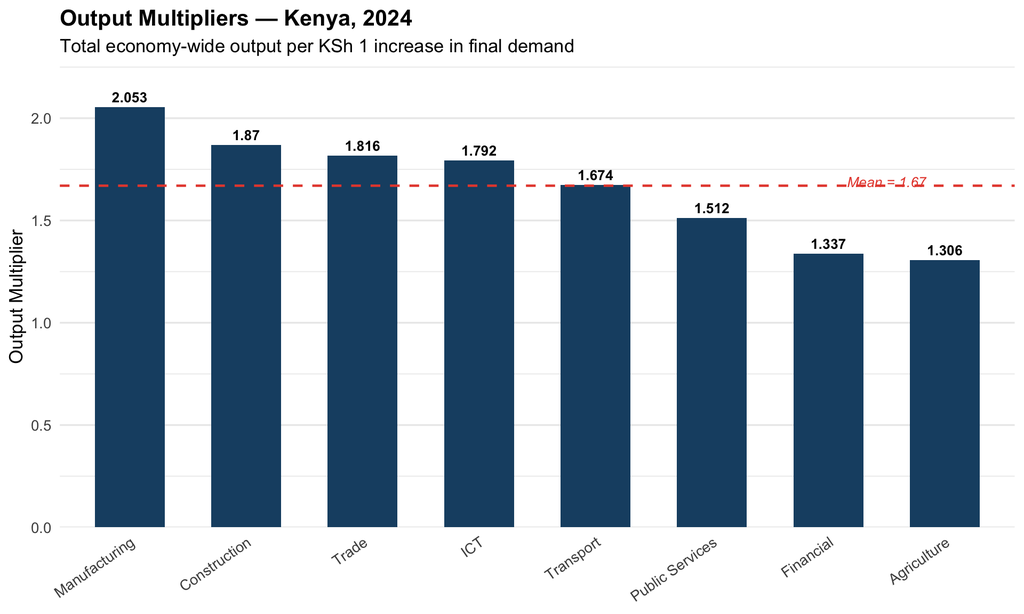

Figure 3: Output Multipliers by Sector

```r
mult_df$Sector <- factor(mult_df$Sector, levels = mult_df$Sector)

ggplot(mult_df, aes(x = Sector, y = Multiplier)) +
  geom_col(fill = "#1B4F72", width = 0.6) +
  geom_hline(yintercept = mean(output_multipliers), linetype = "dashed",
             color = "#E74C3C", linewidth = 0.8) +
  geom_text(aes(label = round(Multiplier, 3)), vjust = -0.5, size = 3.5,
            fontface = "bold") +
  annotate("text", x = n - 0.5, y = mean(output_multipliers) + 0.02,
           label = paste0("Mean = ", round(mean(output_multipliers), 3)),
           color = "#E74C3C", fontface = "italic", size = 3.5) +
  labs(
    title = "Output Multipliers — Kenya, 2024",
    subtitle = "Total economy-wide output per KSh 1 increase in final demand",
    x = NULL,
    y = "Output Multiplier"
  ) +
  theme_minimal(base_size = 13) +
  theme(
    axis.text.x = element_text(angle = 35, hjust = 1),
    plot.title = element_text(face = "bold"),
    panel.grid.major.x = element_blank()
  ) +
  scale_y_continuous(expand = expansion(mult = c(0, 0.1)))
```

## 6.2 Backward and Forward Linkages

Backward and forward linkage indices provide a complementary perspective on sectoral interdependence (Rasmussen, 1956):

- **Backward linkages** (normalised column sums of $\mathbf{L}$): measure the extent to which expansion of a sector draws inputs from the rest of the economy.
- **Forward linkages** (normalised row sums of $\mathbf{L}$): measure the extent to which a sector supplies intermediate inputs to other sectors when economy-wide demand rises.

Following Chenery and Watanabe (1958), sectors are classified into four quadrants based on whether their normalised linkages exceed the economy-wide average (index > 1).

```r
backward <- colSums(L)
forward  <- rowSums(L)

# Normalise relative to economy-wide mean
backward_norm <- backward / mean(backward)
forward_norm  <- forward / mean(forward)

linkage_df <- data.frame(
  Sector   = sectors,
  Backward = round(backward_norm, 3),
  Forward  = round(forward_norm, 3),
  Classification = ifelse(
    backward_norm > 1 & forward_norm > 1, "Key Sector",
    ifelse(backward_norm > 1, "Strong Backward",
           ifelse(forward_norm > 1, "Strong Forward", "Weak Linkage"))
  )
)

knitr::kable(linkage_df,
             caption = "Table 3: Normalised Backward and Forward Linkages",
             align = c("l", "r", "r", "l"))
```

Table 3: Normalised Backward and Forward Linkages

|  | Sector | Backward | Forward | Classification |
| --- | --- | --- | --- | --- |
| Agriculture | Agriculture | 0.782 | 1.172 | Strong Forward |
| Manufacturing | Manufacturing | 1.230 | 1.167 | Key Sector |
| Construction | Construction | 1.120 | 0.877 | Strong Backward |
| Trade | Trade | 1.087 | 0.908 | Strong Backward |
| Transport | Transport | 1.003 | 1.045 | Key Sector |
| Financial | Financial | 0.800 | 0.806 | Weak Linkage |
| ICT | ICT | 1.073 | 0.689 | Strong Backward |
| Public Services | Public Services | 0.905 | 1.336 | Strong Forward |

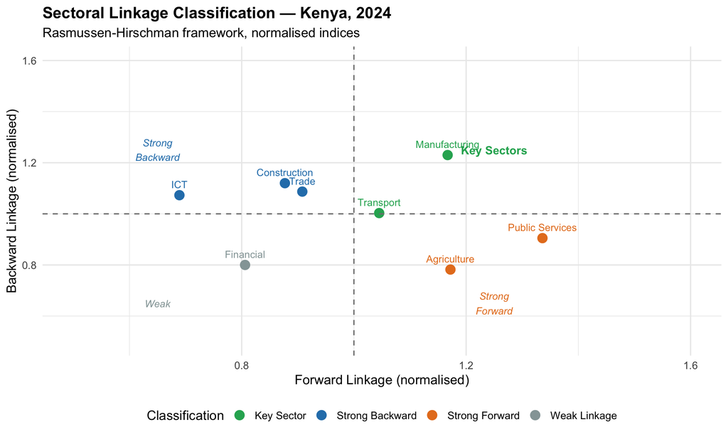

Figure 4: Backward vs Forward Linkages (Normalised)

```r
ggplot(linkage_df, aes(x = Forward, y = Backward, label = Sector, color = Classification)) +
  geom_point(size = 4) +
  geom_text(vjust = -1, size = 3.5, show.legend = FALSE) +
  geom_hline(yintercept = 1, linetype = "dashed", color = "grey50") +
  geom_vline(xintercept = 1, linetype = "dashed", color = "grey50") +
  annotate("text", x = 1.25, y = 1.25, label = "Key Sectors",
           color = "#27AE60", fontface = "bold", size = 4) +
  annotate("text", x = 0.65, y = 1.25, label = "Strong\nBackward",
           color = "#2980B9", fontface = "italic", size = 3.5) +
  annotate("text", x = 1.25, y = 0.65, label = "Strong\nForward",
           color = "#E67E22", fontface = "italic", size = 3.5) +
  annotate("text", x = 0.65, y = 0.65, label = "Weak",
           color = "#95A5A6", fontface = "italic", size = 3.5) +
  scale_color_manual(values = c(
    "Key Sector"       = "#27AE60",
    "Strong Backward"  = "#2980B9",
    "Strong Forward"   = "#E67E22",
    "Weak Linkage"     = "#95A5A6"
  )) +
  labs(
    title = "Sectoral Linkage Classification — Kenya, 2024",
    subtitle = "Rasmussen-Hirschman framework, normalised indices",
    x = "Forward Linkage (normalised)",
    y = "Backward Linkage (normalised)",
    color = "Classification"
  ) +
  theme_minimal(base_size = 13) +
  theme(
    plot.title = element_text(face = "bold"),
    legend.position = "bottom"
  ) +
  coord_cartesian(xlim = c(0.5, 1.6), ylim = c(0.5, 1.6))
```

## 6.3 Demand Shock Simulation

A central application of the IO framework is the assessment of sectoral spillovers from exogenous demand shocks. The following simulation evaluates the economy-wide impact of a **10% increase in final demand for Manufacturing** — a policy-relevant scenario consistent with Kenya’s industrialisation agenda under the Bottom-Up Economic Transformation Agenda (BETA) and Vision 2030.

The impact vector is computed as:

$$\Delta \mathbf{X} = \mathbf{L} \times \Delta \mathbf{F}$$

```r
# ── Demand shock: +10% in Manufacturing final demand ──
shock <- rep(0, n)
shock[2] <- 0.10 * final_demand[2]  # 10% of Manufacturing final demand

names(shock) <- sectors
cat("Demand Shock Vector (KSh Million):\n")
```

```
## Demand Shock Vector (KSh Million):
```

```r
print(round(shock, 0))
```

```
##     Agriculture   Manufacturing    Construction           Trade       Transport
##               0          128536               0               0               0
##       Financial             ICT Public Services
##               0               0               0
```

```r
# ── Impact on total output ──
impact <- L %*% shock

impact_df <- data.frame(
  Sector = sectors,
  `Baseline Output` = format(round(total_output, 0), big.mark = ","),
  `Change in Output` = format(round(as.vector(impact), 0), big.mark = ","),
  `Pct Change` = paste0(round(as.vector(impact) / total_output * 100, 2), "%"),
  check.names = FALSE
)

knitr::kable(impact_df,
             caption = "Table 4: Impact of 10% Increase in Manufacturing Final Demand",
             align = c("l", "r", "r", "r"))
```

Table 4: Impact of 10% Increase in Manufacturing Final Demand

|  | Sector | Baseline Output | Change in Output | Pct Change |
| --- | --- | --- | --- | --- |
| Agriculture | Agriculture | 4,476,418 | 24,193 | 0.54% |
| Manufacturing | Manufacturing | 4,435,186 | 152,506 | 3.44% |
| Construction | Construction | 2,171,266 | 11,734 | 0.54% |
| Trade | Trade | 2,412,339 | 13,037 | 0.54% |
| Transport | Transport | 3,484,863 | 18,834 | 0.54% |
| Financial | Financial | 1,614,214 | 8,724 | 0.54% |
| ICT | ICT | 701,267 | 3,790 | 0.54% |
| Public Services | Public Services | 5,758,435 | 31,121 | 0.54% |

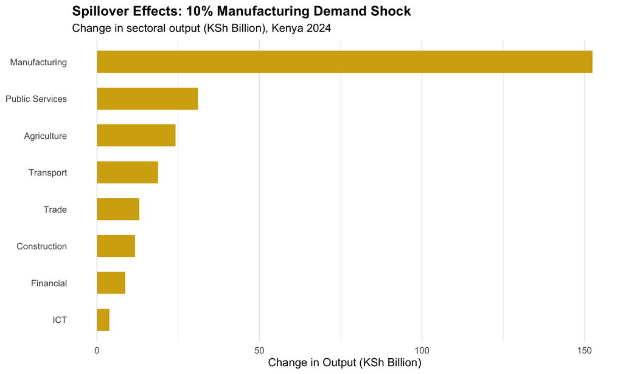

Figure 5: Spillover Effects of a Manufacturing Demand Shock

```r
shock_plot <- data.frame(
  Sector = factor(sectors, levels = sectors[order(as.vector(impact))]),
  Impact = as.vector(impact) / 1e3
)

ggplot(shock_plot, aes(x = Sector, y = Impact)) +
  geom_col(fill = "#D4AC0D", width = 0.6) +
  coord_flip() +
  labs(
    title = "Spillover Effects: 10% Manufacturing Demand Shock",
    subtitle = "Change in sectoral output (KSh Billion), Kenya 2024",
    x = NULL,
    y = "Change in Output (KSh Billion)"
  ) +
  theme_minimal(base_size = 13) +
  theme(
    plot.title = element_text(face = "bold"),
    panel.grid.major.y = element_blank()
  )
```